# Practical Machine Learning Project - Exercise Predictor Report

Arun Krishnasamy

## Introduction

Using devices such as Jawbone Up, Nike FuelBand, and Fitbit it is now possible to collect a large amount of data about personal activity relatively inexpensively. These type of devices are part of the quantified self movement â a group of enthusiasts who take measurements about themselves regularly to improve their health, to find patterns in their behavior, or because they are tech geeks. One thing that people regularly do is quantify how much of a particular activity they do, but they rarely quantify how well they do it.

In this project, we will use data from accelerometers on the belt, forearm, arm, and dumbell of 6 participants to predict the manner in which they did the exercise.

## Loading the required packages

```r
library(caret)
```

```r
library(rpart)
library(rpart.plot)
library(randomForest)
library(corrplot)
setInternet2(TRUE)
library(downloader)
```

### Download the Data

```r
traindataUrl <- "http://d396qusza40orc.cloudfront.net/predmachlearn/pml-training.csv"
testdataUrl <- "http://d396qusza40orc.cloudfront.net/predmachlearn/pml-testing.csv"
traindataFile <- "./data/pml-training.csv"
testdataFile  <- "./data/pml-testing.csv"

if (!file.exists("./data")) {
  dir.create("./data")
}

if (!file.exists(traindataFile)) {
  download(traindataUrl, destfile = traindataFile)
}
if (!file.exists(testdataFile)) {
  download(testdataUrl, destfile = testdataFile)
}
```

### Read the Downloaded Data

Reading the two csv files into two data frames.

```r
# reading the data from CSV files to a vectos
#
traindataRaw <- read.csv("./data/pml-training.csv")
testdataRaw <- read.csv("./data/pml-testing.csv")
dim(traindataRaw)
```

```
## [1] 19622   160
```

```r
dim(testdataRaw)
```

```
## [1]  20 160
```

### Exploratory Data Analysis process

The training data has 19622 observations and 160 variables, while the testing data set contains 20 observations and 160 variables. The “classe” variable in the training set is the outcome to predict.

```r
## assign the summary table of the training data set to the variable summ
summ_traindataRaw <- summary(traindataRaw)
dim(summ_traindataRaw)
```

```
## [1]   7 160
```

```r
sum(complete.cases(traindataRaw))
```

```
## [1] 406
```

### Data Cleansing process

Data cleansing to eliminate missing values and what i think as useless variables for this exercise

First, we remove columns that contain NA missing values.

```r
## remove the column with the NA's

traindataRaw <- traindataRaw[, colSums(is.na(traindataRaw)) == 0]
testdataRaw <- testdataRaw[, colSums(is.na(testdataRaw)) == 0]

## remove the column with the row number
traindataRaw$X <- NULL
```

Next, remove some columns that do not contribute much to the accelerometer measurements.

```r
## cleaning the training data; removing the unnecessary columns

classe <- traindataRaw$classe
trainRemove <- grepl("^X|timestamp|window", names(traindataRaw))
traindataRaw <- traindataRaw[, !trainRemove]
traindataCleaned <- traindataRaw[, sapply(traindataRaw, is.numeric)]
traindataCleaned$classe <- classe

## cleaning the test data

testRemove <- grepl("^X|timestamp|window", names(testdataRaw))
testdataRaw <- testdataRaw[, !testRemove]
testdataCleaned <- testdataRaw[, sapply(testdataRaw, is.numeric)]
```

Now, the cleaned training data set contains 19622 observations and 53 variables, while the testing data set contains 20 observations and 53 variables. The “classe” variable is still in the cleaned training set.

```r
## create a variable to represent the x-axis as "classe" is a factor and
## histograms can only be drawn for numeric data
traindataCleanedclassnum <- as.numeric(traindataCleaned$classe)

## create the histogram and change its density to percentages
traindataCleanedhistogram <- hist(traindataCleanedclassnum)
traindataCleanedhistogram$density <- traindataCleanedhistogram$counts / sum(traindataCleanedhistogram$counts) * 100
```

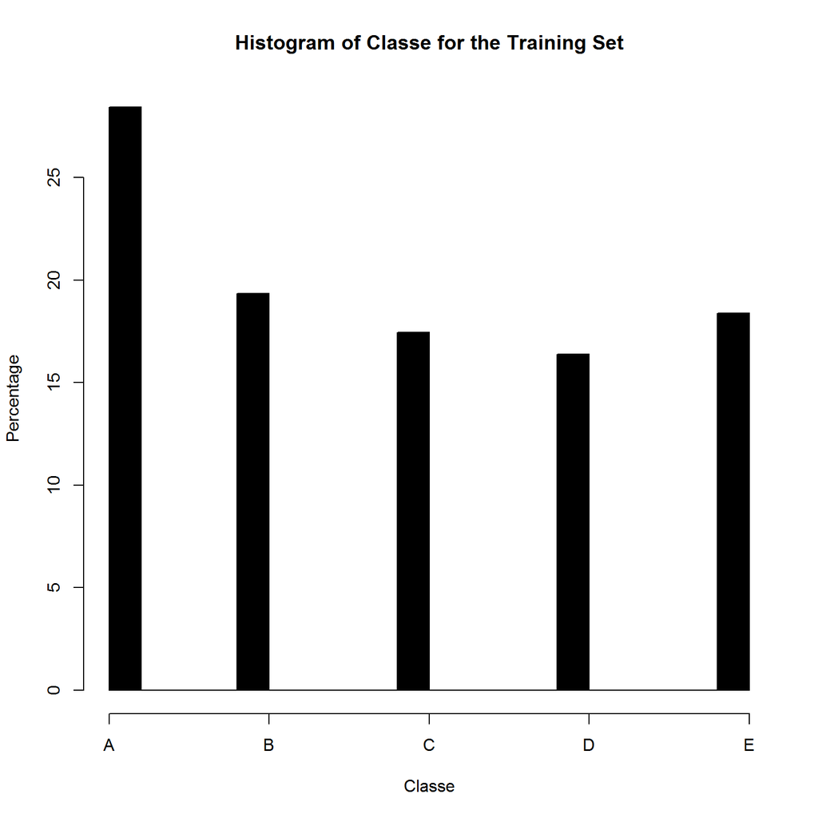

```r
## plot the histogram, leaving the x-axis blank
plot(traindataCleanedhistogram, freq = F, main = "Histogram of Classe for the Training Set", ylab =
         "Percentage", xlab ="Classe", xaxt = "n", col = "black")

## add the axis
axis(1,at = 1:5,labels = c("A","B","C","D","E"))
```

### Slice the data

Then, we can split the cleaned training set into a pure training data set (60%) and a validation data set (40%). We will use the validation data set to conduct cross validation in future steps.

```r
set.seed(50000) # For reproducibile random#

inTrainData <- createDataPartition(traindataCleaned$classe, p = 0.60, list = F)
trainData <- traindataCleaned[inTrainData, ]
testData <- traindataCleaned[-inTrainData, ]
```

## Random Forest Data Modeling

We will use a predictive model for activity recognition using **Random Forest** algorithm because it automatically selects important variables and is robust to correlated covariates & outliers in general. We will use **10-fold cross validation** when applying the algorithm.

```r
controlfactorRf <- trainControl(method = "cv", 10)

trainmodelRf <- train(classe ~ ., data = trainData, method = "rf", trControl = controlfactorRf, ntree = 250)

trainmodelRf
```

```
## Random Forest
##
## 11776 samples
##    52 predictor
##     5 classes: 'A', 'B', 'C', 'D', 'E'
##
## No pre-processing
## Resampling: Cross-Validated (10 fold)
## Summary of sample sizes: 10599, 10597, 10600, 10599, 10599, 10597, ...
## Resampling results across tuning parameters:
##
##   mtry  Accuracy   Kappa      Accuracy SD  Kappa SD
##    2    0.9900642  0.9874299  0.002501564  0.003165052
##   27    0.9899801  0.9873243  0.002646149  0.003349299
##   52    0.9847150  0.9806647  0.002590809  0.003275984
##
## Accuracy was used to select the optimal model using  the largest value.
## The final value used for the model was mtry = 2.
```

Determine the performance of the model on the validation data set.

```r
trainpredictRf <- predict(trainmodelRf, testData)
confusionMatrix(testData$classe, trainpredictRf)
```

```
## Confusion Matrix and Statistics
##
##           Reference
## Prediction    A    B    C    D    E
##          A 2231    0    1    0    0
##          B   13 1505    0    0    0
##          C    0    7 1360    1    0
##          D    0    0   32 1252    2
##          E    0    0    0    3 1439
##
## Overall Statistics
##
##                Accuracy : 0.9925
##                  95% CI : (0.9903, 0.9943)
##     No Information Rate : 0.286
##     P-Value [Acc > NIR] : < 2.2e-16
##
##                   Kappa : 0.9905
##  Mcnemar's Test P-Value : NA
##
## Statistics by Class:
##
##                      Class: A Class: B Class: C Class: D Class: E
## Sensitivity            0.9942   0.9954   0.9763   0.9968   0.9986
## Specificity            0.9998   0.9979   0.9988   0.9948   0.9995
## Pos Pred Value         0.9996   0.9914   0.9942   0.9736   0.9979
## Neg Pred Value         0.9977   0.9989   0.9949   0.9994   0.9997
## Prevalence             0.2860   0.1927   0.1775   0.1601   0.1837
## Detection Rate         0.2843   0.1918   0.1733   0.1596   0.1834
## Detection Prevalence   0.2845   0.1935   0.1744   0.1639   0.1838
## Balanced Accuracy      0.9970   0.9967   0.9875   0.9958   0.9991
```

Looking for the accuracy and sample error metrics

```r
modelaccuracy <- postResample(trainpredictRf, testData$classe)
modelaccuracy
```

```
##  Accuracy     Kappa
## 0.9924802 0.9904862
```

```r
sampleerror <- 1 - as.numeric(confusionMatrix(testData$classe, trainpredictRf)$overall[1])
sampleerror
```

```
## [1] 0.007519755
```

## Predicting for Test Data Set

Applying the model to the original testing data set downloaded from the data source. We may remove the `problem_id` column first.

```r
## predict the training set and store the results in a character vector
output <- predict(trainmodelRf, testdataCleaned[, -length(names(testdataCleaned))])


## display the predictions
output
```

```
##  [1] B A B A A E D B A A B C B A E E A B B B
## Levels: A B C D E
```

### Output files

Per the assignment, the prediction algorithm created above is applied to the twenty (20) cases in the testing data set. For each test case, a text file is created with a single capital letter (A, B, C, D, or E) corresponding to the prediction for the corresponding problem in the test data set. These files were then manually submitted to Coursera for grading.

```r
## create a directory called "test_output," suppressing warnings if the Directory already exists

dir.create(file.path("project_output"), showWarnings = FALSE)

## create a function to write the files to be submitted
write_files = function(x){
    n = length(x)
    for(i in 1:n){
        filename = paste0("project_output/problem_id_", i, ".txt")
        write.table(x[i], file = filename, quote = FALSE, row.names = FALSE,
                    col.names = FALSE)
    }
}

## then create the files, one for each prediction
write_files(output)
```